# Network Intrusion Project - Group M

Tongyu Zhao, Kyle Soto, Hayden Moore

2021/3/17

## Introduction: Data and Problem summary

For this project we were given a dataset composed of network features and activities with the goal of trying to understand what features classify an intrusion. We wanted to be able to classify these intrusions into different clusters to try and fully understand the attack vector. In this document you will see our process of exploring our data, predicting with our models, and then finally creating a narrative to explain the various intrusions we were able to detect in our dataset.

## Section 1: Exploratory Data Analysis

#### Preamble: Loading packages and data

```r
library(tidyverse)
library(ggplot2)
library(ISLR)
library(tree)
library(partykit)
library(caret)
library(rpart)
library(randomForest)
library(pROC)
library(knitr)
library(factoextra)
library(ggpubr)
library(e1071) #Naive bayes classifier
library(MASS) #lda
library(class) #KNN
```

#### 1.1 load the data file & clean the data

```r
# load the data file
intrusion <- read.csv("network_traffic.csv")
# clean the data : remove NA
intrusion$is_intrusion <- as.numeric(intrusion$is_intrusion)
intrusion <- na.omit(intrusion)

intrusion <- within(intrusion, {

  flag <- factor(flag)
  is_intrusion <- factor(is_intrusion)

})

# get a data set where observations' `is_intrusion` label is 1
intrusions.true <- intrusion[intrusion$is_intrusion == 1, ]
# save a copy for k-clustering labels
intrusions.cluster <- intrusions.true
```

#### 1.2

```r
summary(intrusion)
```

```
##     duration       protocol_type        service            flag
##  Min.   :    0.0   Length:2999        Length:2999        REJ : 154
##  1st Qu.:    0.0   Class :character   Class :character   RSTO:   1
##  Median :    0.0   Mode  :character   Mode  :character   RSTR:  65
##  Mean   :  118.1                                         S0  :  33
##  3rd Qu.:    0.0                                         S3  :   2
##  Max.   :24204.0                                         SF  :2744
##    src_bytes          dst_bytes           land   wrong_fragment     urgent
##  Min.   :     0.0   Min.   :     0   Min.   :0   Min.   :0      Min.   :0
##  1st Qu.:   132.5   1st Qu.:   118   1st Qu.:0   1st Qu.:0      1st Qu.:0
##  Median :   228.0   Median :   388   Median :0   Median :0      Median :0
##  Mean   :  4569.2   Mean   :  2705   Mean   :0   Mean   :0      Mean   :0
##  3rd Qu.:   316.0   3rd Qu.:  1952   3rd Qu.:0   3rd Qu.:0      3rd Qu.:0
##  Max.   :283618.0   Max.   :273544   Max.   :0   Max.   :0      Max.   :0
##       hot           num_failed_logins   logged_in      num_compromised
##  Min.   : 0.00000   Min.   :0         Min.   :0.0000   Min.   :  0.0000
##  1st Qu.: 0.00000   1st Qu.:0         1st Qu.:0.0000   1st Qu.:  0.0000
##  Median : 0.00000   Median :0         Median :1.0000   Median :  0.0000
##  Mean   : 0.06602   Mean   :0         Mean   :0.7176   Mean   :  0.2968
##  3rd Qu.: 0.00000   3rd Qu.:0         3rd Qu.:1.0000   3rd Qu.:  0.0000
##  Max.   :25.00000   Max.   :0         Max.   :1.0000   Max.   :884.0000
##    root_shell     su_attempted          num_root        num_file_creations
##  Min.   :0.000   Min.   :0.0000000   Min.   :  0.0000   Min.   :0.000
##  1st Qu.:0.000   1st Qu.:0.0000000   1st Qu.:  0.0000   1st Qu.:0.000
##  Median :0.000   Median :0.0000000   Median :  0.0000   Median :0.000
##  Mean   :0.001   Mean   :0.0006669   Mean   :  0.3478   Mean   :0.001
##  3rd Qu.:0.000   3rd Qu.:0.0000000   3rd Qu.:  0.0000   3rd Qu.:0.000
##  Max.   :1.000   Max.   :2.0000000   Max.   :975.0000   Max.   :1.000
##    num_shells        num_access_files   num_outbound_cmds is_host_login
##  Min.   :0.0000000   Min.   :0.000000   Min.   :0         Min.   :0
##  1st Qu.:0.0000000   1st Qu.:0.000000   1st Qu.:0         1st Qu.:0
##  Median :0.0000000   Median :0.000000   Median :0         Median :0
##  Mean   :0.0003334   Mean   :0.004668   Mean   :0         Mean   :0
##  3rd Qu.:0.0000000   3rd Qu.:0.000000   3rd Qu.:0         3rd Qu.:0
##  Max.   :1.0000000   Max.   :5.000000   Max.   :0         Max.   :0
##  is_guest_login  is_intrusion
##  Min.   :0.000   0:2699
##  1st Qu.:0.000   1: 300
##  Median :0.000
##  Mean   :0.015
##  3rd Qu.:0.000
##  Max.   :1.000
```

```r
analysis <- intrusion


intrusion <- within(intrusion, {
    is_intrusion <- factor(is_intrusion)
})

analysis <- within(analysis, {
    land <- factor(land)
    logged_in <- factor(logged_in)
    is_host_login <- factor(is_host_login)
    is_guest_login <- factor(is_guest_login)
    su_attempted <- factor(su_attempted)
    root_shell <- factor(root_shell)
    num_shells <- factor(num_shells)
    num_access_files <- factor(num_access_files)
    flag <- factor(flag)
    is_intrusion <- factor(is_intrusion)

})
```

We see a number of columns using indicator variables, these aren’t suitable as ints to understand, so we convert them to factor, also since this datastet is zero inflated I’ll convert variables with low variance into factors

Now lets see how different variables relate to intrusions

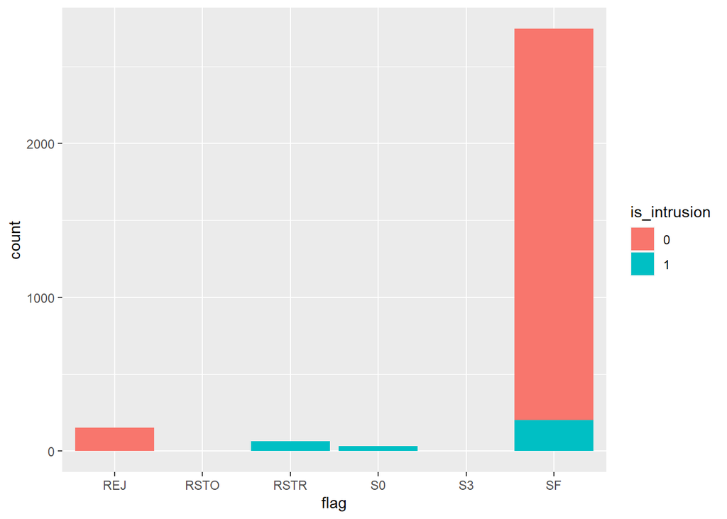

```r
ggplot(analysis, aes(x=flag, fill =is_intrusion)) +
  geom_bar()
```

Flag : We see that RSTR, s0, and s3 are reliably intrusions, and a portion of SF flags are intrusions as well.

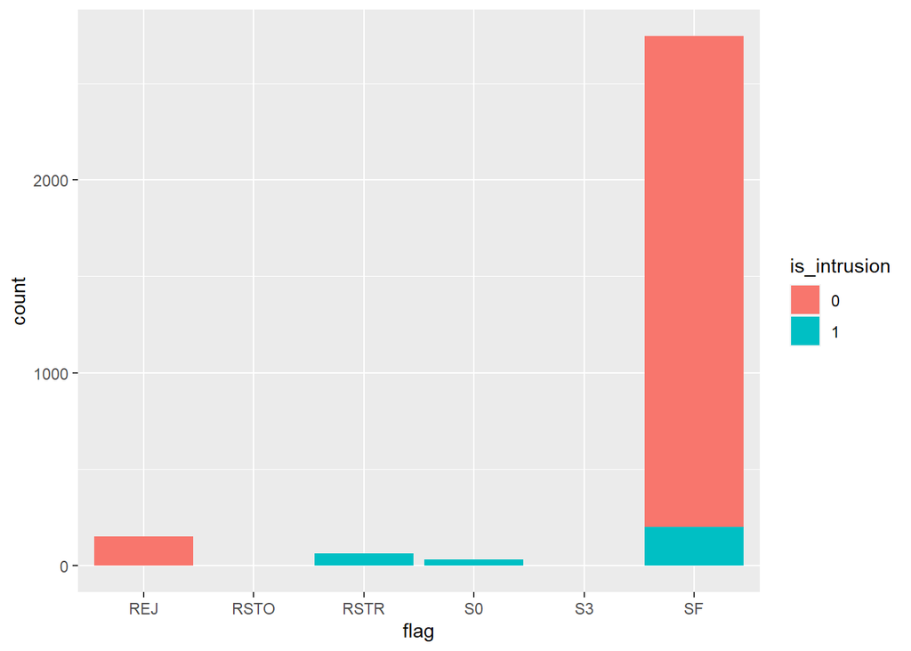

```r
ggplot(analysis, aes(x=flag, fill =is_intrusion)) +
  geom_bar()
```

logged in: While intrusions are more likely to occur when not registering a login, they happen as both logged in attacks and not

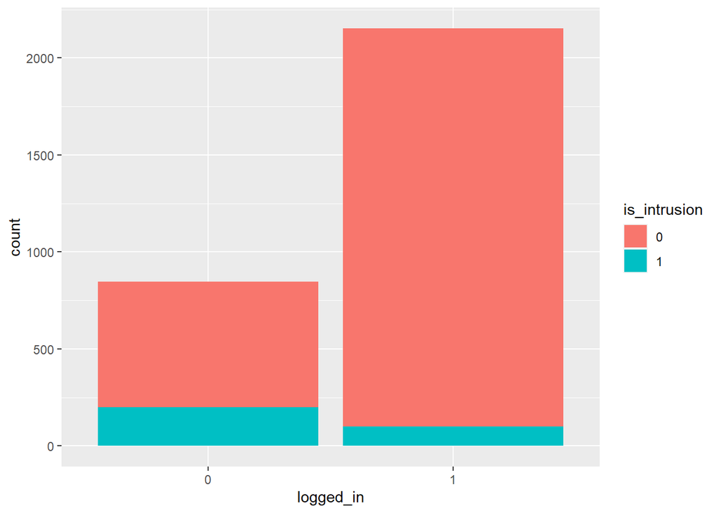

```r
ggplot(analysis, aes(x=logged_in, fill =is_intrusion)) +
  geom_bar()
```

logged in attacks: We see that logins that are intrusions not only last longer, but generally use more source bytes suggesting these may be timing out. Logins that are intrusions are clustering above 50,000 source bytes

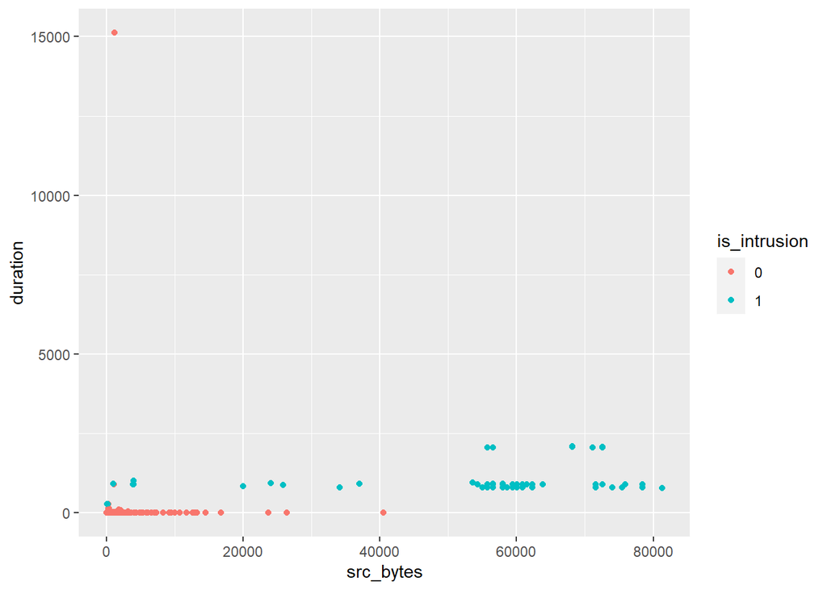

```r
logins <- subset(analysis, logged_in == 1)
ggplot(logins, aes(x=src_bytes, y=duration, color = is_intrusion)) +
  geom_point()
```

Is the same true of those not logged in

Not logged in attacks: We see that logouts are similarly generating huge numbers of source byte, but there is not any duration time. The duration and amount of source bytes generated during logged out attacks is uniform. How many of these uniform attacks are there

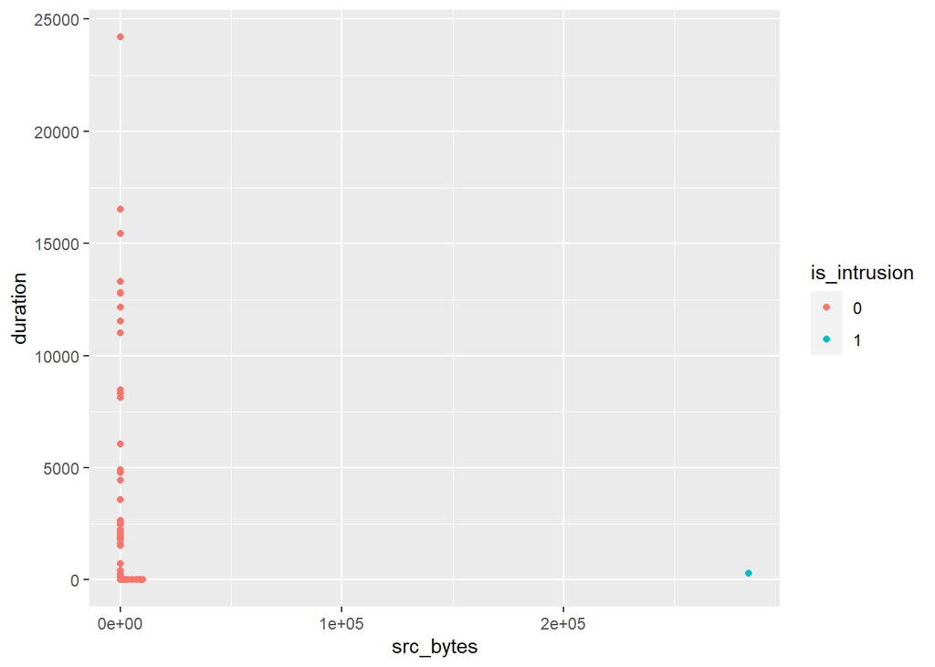

```r
logouts <- subset(analysis, logged_in == 0)
ggplot(logouts, aes(x=src_bytes, y=duration, color = is_intrusion)) +
  geom_point()
```

```r
uniform.attack <- table(logouts$is_intrusion)
```

Further investigation reveals three or so sizes all with a uniform flag

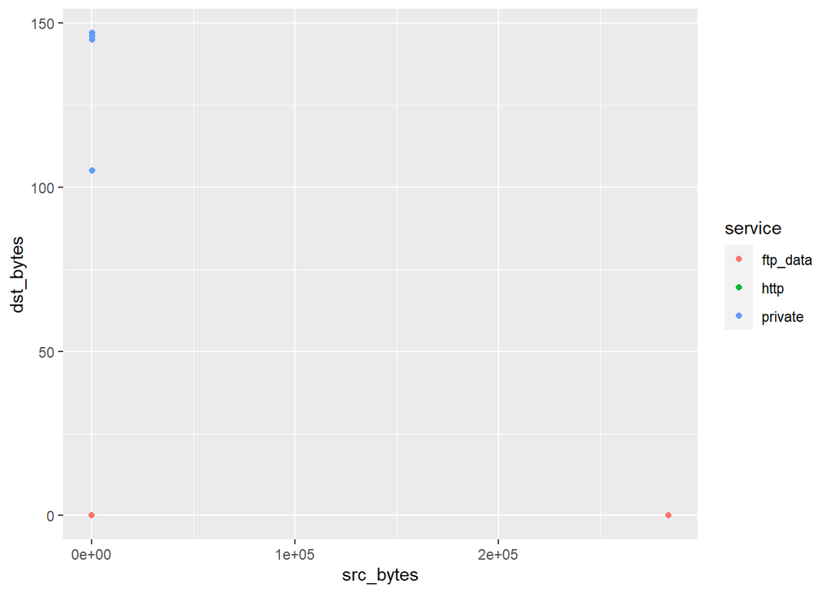

```r
logout.uniform.attack <- subset(logouts, is_intrusion == 1)

ggplot(logout.uniform.attack, aes(x=src_bytes, y=dst_bytes, color =service)) +
  geom_point()
```

Guest login: We see that guest logins are much more likely to produce attacks, but it’s difficult to tell as there aren’t many in our dataset.

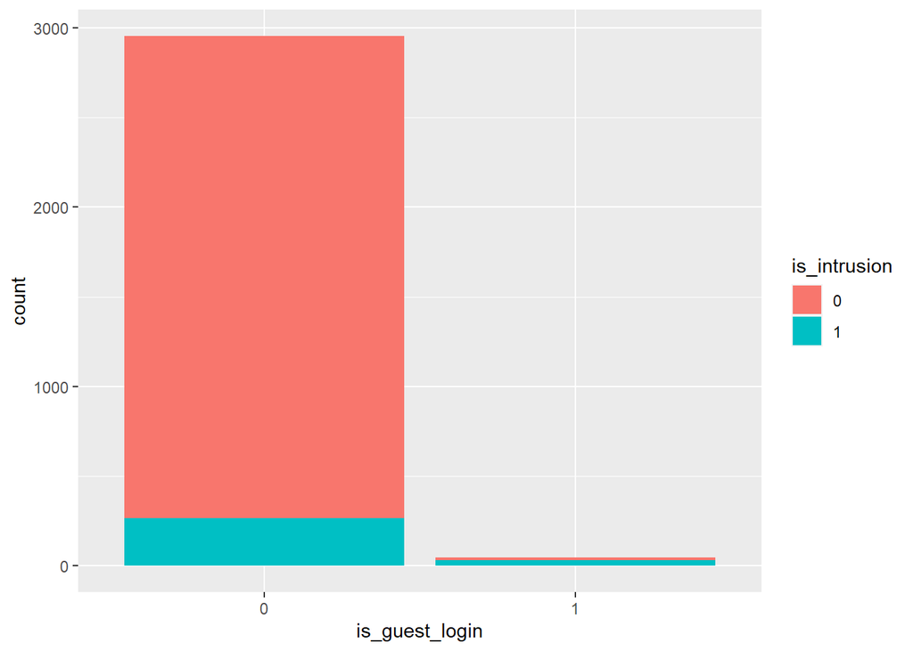

```r
ggplot(analysis, aes(x=is_guest_login, fill =is_intrusion)) +
  geom_bar()
```

Guest login == 1: We split off the guest logins to better understand what’s going on here

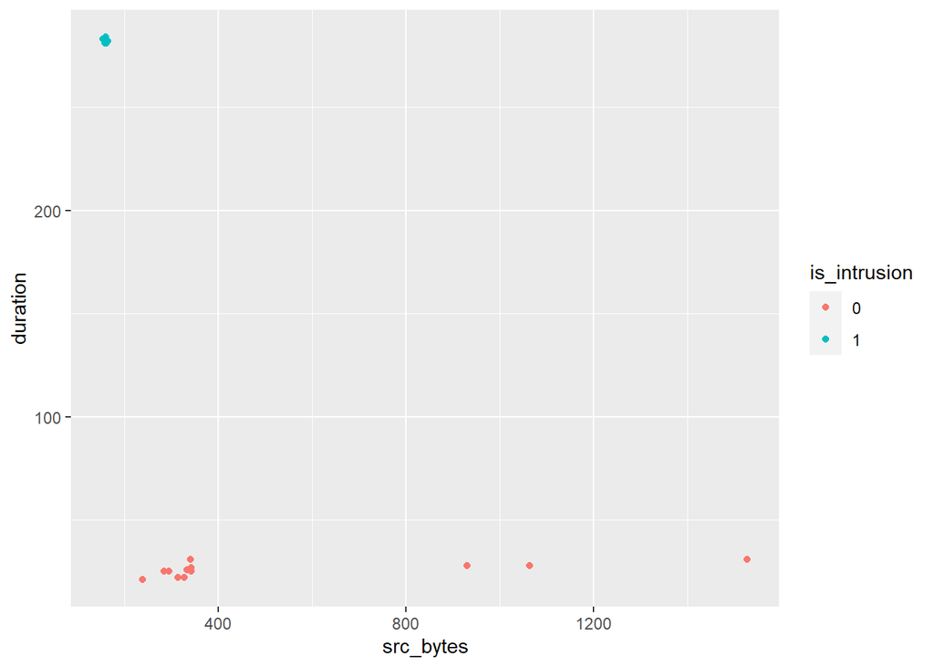

```r
guests <- subset(analysis, is_guest_login == 1)
ggplot(guests, aes(x=src_bytes, y=duration, color = is_intrusion)) +
  geom_point()
```

There seems to be a clustering among guest logins indicating guest logins with high duration times are intrusions. This is something to investigate

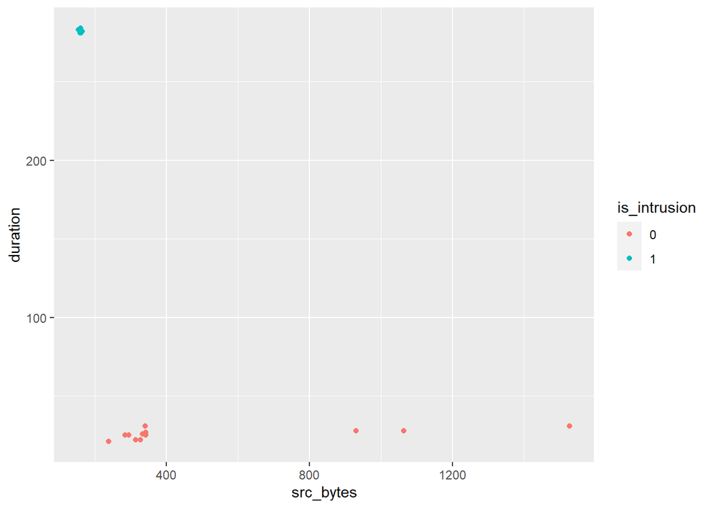

```r
ggplot(guests, aes(x=src_bytes, y=duration, color = is_intrusion)) +
  geom_point()
```

Looking at these plots the duration, source bytes, and login status, seem critical to assessing whether or not an intrusion has taken place

## Section 2: Methodology

### 2.1 Data processing

```r
# To do: name and assign all the data sets used here

set.seed(981)
# randomly upsample the data set for final testing (try to maintain the same proportion)
intrusion.rand <- sample(1:nrow(intrusion), 20000, replace = TRUE)
# upsample `is_intrusion` == 1 data for modeling (try to balance the data set)
intrusion.more.idx <- sample(which(intrusion$is_intrusion == 1), 1700, replace = TRUE)
intrusion.upsample.rand <- rbind(intrusion,
                            intrusion[intrusion.rand, ])
intrusion.upsample <- rbind(intrusion,
                            intrusion[intrusion.more.idx, ])

# separate intrusion.upsample into training and test set
test.indexes <- sample(1:nrow(intrusion.upsample),
                       round(0.2 * nrow(intrusion.upsample)))
train.indexes <- setdiff(1:nrow(intrusion.upsample), test.indexes)

intrusion.train <- intrusion.upsample[train.indexes,]
intrusion.test <- intrusion.upsample[test.indexes,]
```

### 2.2 Prediction

#### (a)Decision Tree

##### Build a decision tree using training data

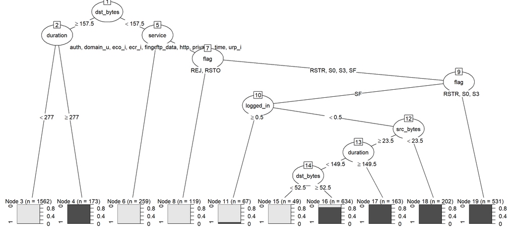

```r
# Decision Tree
intrusion.train$is_intrusion = as.factor(intrusion.train$is_intrusion)
intrusion.tree = rpart(is_intrusion~., intrusion.train)

#summary(intrusion.tree)

intrusion.party <- as.party(intrusion.tree)

plot(intrusion.party)
```

```r
print(intrusion.party)
```

```
##
## Model formula:
## is_intrusion ~ duration + protocol_type + service + flag + src_bytes +
##     dst_bytes + land + wrong_fragment + urgent + hot + num_failed_logins +
##     logged_in + num_compromised + root_shell + su_attempted +
##     num_root + num_file_creations + num_shells + num_access_files +
##     num_outbound_cmds + is_host_login + is_guest_login
##
## Fitted party:
## [1] root
## |   [2] dst_bytes >= 157.5
## |   |   [3] duration < 277: 0 (n = 1562, err = 0.0%)
## |   |   [4] duration >= 277: 1 (n = 173, err = 0.6%)
## |   [5] dst_bytes < 157.5
## |   |   [6] service in auth, domain_u, eco_i, ecr_i, finger, ntp_u, other, pop_3, time, urp_i: 0 (n = 259, err = 0.0%)
## |   |   [7] service in ftp_data, http, private
## |   |   |   [8] flag in REJ, RSTO: 0 (n = 119, err = 0.0%)
## |   |   |   [9] flag in RSTR, S0, S3, SF
## |   |   |   |   [10] flag in SF
## |   |   |   |   |   [11] logged_in >= 0.5: 0 (n = 67, err = 7.5%)
## |   |   |   |   |   [12] logged_in < 0.5
## |   |   |   |   |   |   [13] src_bytes >= 23.5
## |   |   |   |   |   |   |   [14] duration < 149.5
## |   |   |   |   |   |   |   |   [15] dst_bytes < 52.5: 0 (n = 49, err = 0.0%)
## |   |   |   |   |   |   |   |   [16] dst_bytes >= 52.5: 1 (n = 634, err = 14.7%)
## |   |   |   |   |   |   |   [17] duration >= 149.5: 1 (n = 163, err = 0.0%)
## |   |   |   |   |   |   [18] src_bytes < 23.5: 1 (n = 202, err = 0.0%)
## |   |   |   |   [19] flag in RSTR, S0, S3: 1 (n = 531, err = 0.0%)
##
## Number of inner nodes:     9
## Number of terminal nodes: 10
```

##### 10-Fold Cross-validation pruning on `intrusion.tree`

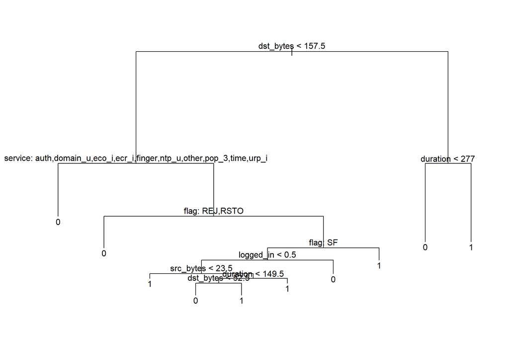

```r
#set.seed(2)
intrusion.cv.train = intrusion.train

intrusion.cv.train[,2] = as.factor(intrusion.cv.train[,2])
intrusion.cv.train[,3] = as.factor(intrusion.cv.train[,3])
intrusion.cv.train[,4] = as.factor(intrusion.cv.train[,4])

intrusion.full.tree = tree(is_intrusion~., intrusion.cv.train)

plot(intrusion.full.tree)
text(intrusion.full.tree, pretty = 0)
```

```r
intrusion.cv.tree = cv.tree(intrusion.full.tree, FUN = prune.misclass)

intrusion.cv.tree
```

```
## $size
## [1] 10  7  5  4  3  2  1
##
## $dev
## [1]  104  152  209  327  497  754 1614
##
## $k
## [1]      -Inf  16.33333  28.50000 119.00000 171.00000 259.00000 860.00000
##
## $method
## [1] "misclass"
##
## attr(,"class")
## [1] "prune"         "tree.sequence"
```

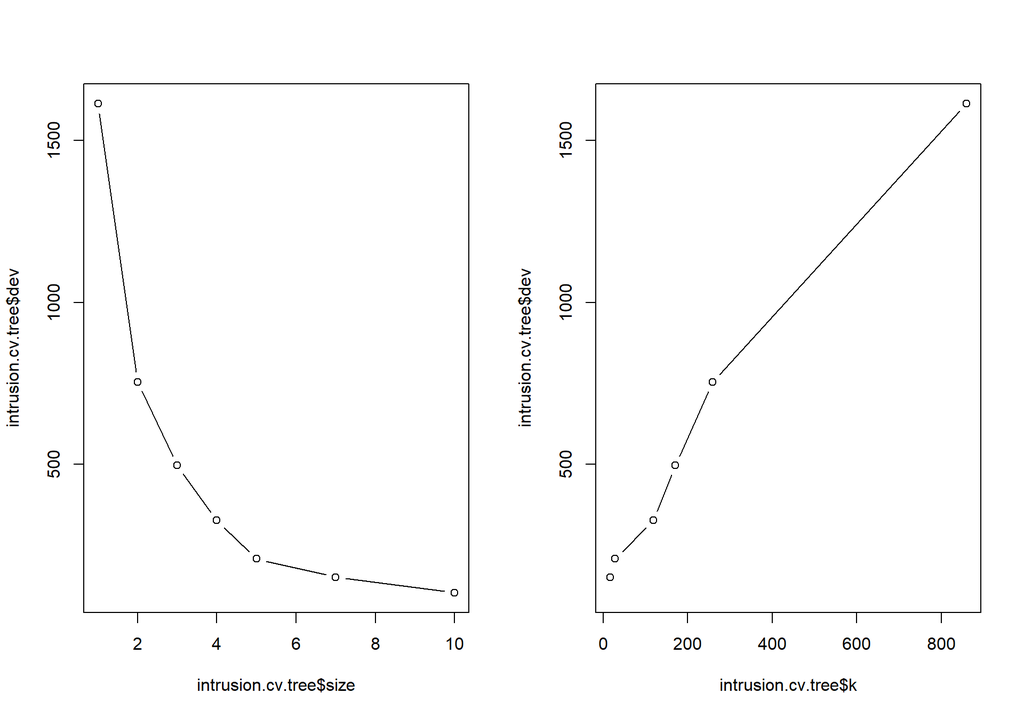

```r
par(mfrow = c(1,2))
plot(intrusion.cv.tree$size, intrusion.cv.tree$dev, type="b")
plot(intrusion.cv.tree$k, intrusion.cv.tree$dev, type="b")
```

- The lowest CV error tree has 10 leaf nodes, which is consistent with our rpart tree. So we don’t need to prune it.

##### Predict using the tree and see its performance

##### include the ClassMetrics function in HW4

```r
classMetrics <- function(score, y, cutoff,
                         type = c("all", "accuracy", "sensitivity",
                                  "specificity", "ppv", "npv", "precision",
                                  "recall")) {

  # classify the observations based on score and cutoff
  hat.y <- ifelse(score < cutoff, 0, 1)

  # Form confusion matrix
  y = factor(y, levels = c("0","1"))
  hat.y = factor(hat.y, levels = c("0","1"))
  conf.mtrx = table(hat.y, y)

  # Use the appropriate entries in the confusion matrix to calculate all metrics:
  # accuracy, sensitivity, specificity, ppv, npv, precision (which is the same as ppv), recall (which is the same as sensitivity)
  accuracy = (conf.mtrx[1,1]+conf.mtrx[2,2])/sum(conf.mtrx)
  sensitivity = conf.mtrx[2,2]/sum(conf.mtrx[,2])
  specificity = conf.mtrx[1,1]/sum(conf.mtrx[,1])
  ppv = conf.mtrx[2,2]/sum(conf.mtrx[2,])
  npv = conf.mtrx[1,1]/sum(conf.mtrx[1,])
  precision = conf.mtrx[2,2]/sum(conf.mtrx[2,])
  recall = conf.mtrx[2,2]/sum(conf.mtrx[,2])

  # I'm giving you the exact names you should use in your output dataframe
  metric.names <- c("accuracy", "sensitivity", "specificity",
                    "ppv", "npv", "precision", "recall")

  # Form into data frame
  # Your data frame should contain ONLY ONE COLUMN named "value"
  # assign the metric.names above as the rownames of your data frame (just as the rownames, not as a second column!)
  res = data.frame(value = c(accuracy,sensitivity,specificity,ppv,npv,precision,recall), row.names = metric.names)

  # Return a list containing the confusion matrix and the data frame of the metrics
  # If "all", return all metrics. Otherwise, return just the requested subset of metrics
  if(type[1] == "all") {
    res = list(conf.mat = conf.mtrx, perf = res)
  } else {
    tem = data.frame(value = 1)
    i = 0
    for(item in type) {
      i = i+1
      tem[i,1] = res[item,"value"]
    }
    row.names(tem) <- type
    res = list(conf.mat = conf.mtrx, perf = tem)
  }
  res
}
```

##### Do prediction and use the classMetrics function getting the performance metrics of the tree

```r
# use intrusion.test as test data(upsampled to reduce imbalance)
intrusion.pred = predict(intrusion.tree, newdata = intrusion.test)
classMetrics(intrusion.pred[,2], intrusion.test$is_intrusion, cutoff = 0.25, type = "all")
```

```
## $conf.mat
##      y
## hat.y   0   1
##     0 527   0
##     1  27 386
##
## $perf
##                 value
## accuracy    0.9712766
## sensitivity 1.0000000
## specificity 0.9512635
## ppv         0.9346247
## npv         1.0000000
## precision   0.9346247
## recall      1.0000000
```

```r
# use intrusion.upsample.rand as test data(keep the original proportion)
intrusion.pred.rand = predict(intrusion.tree, newdata =intrusion.upsample.rand)
classMetrics(intrusion.pred.rand[,2], intrusion.upsample.rand$is_intrusion, cutoff = 0.25, type = "all")
```

```
## $conf.mat
##      y
## hat.y     0     1
##     0 19742     4
##     1   965  2288
##
## $perf
##                 value
## accuracy    0.9578677
## sensitivity 0.9982548
## specificity 0.9533974
## ppv         0.7033508
## npv         0.9997974
## precision   0.7033508
## recall      0.9982548
```

- Since we want to detect all intrusions, we want a high sensitivity instead of accuracy or specificity, ppv, etc.
- The tree does a pretty good job on intrusion upsampling data that the sensitivity is 1.
- For the random upsampling data, the metrics go down but we still get a very high sensitivity which equals to 0.9983.
- PPV goes down to 0.7034, which means about 30% of our positive predictions are actually not intrusions. But it’s okay because some kinds of attacks try to go over tons of requests and most of the attempts failed. They do not successful intrude, but remain dangerous.

#### (b)Bagging & Random Forest

#### Bagged tree model

```r
# Bagging
#intrusion.train$is_intrusion = as.factor(intrusion.train$is_intrusion)
bag.intrusion <- randomForest(is_intrusion~., intrusion.train, mtry = 5, ntree = 500, importance = TRUE)
bag.intrusion
```

```
##
## Call:
##  randomForest(formula = is_intrusion ~ ., data = intrusion.train,      mtry = 5, ntree = 500, importance = TRUE)
##                Type of random forest: classification
##                      Number of trees: 500
## No. of variables tried at each split: 5
##
##         OOB estimate of  error rate: 3.48%
## Confusion matrix:
##      0    1 class.error
## 0 2014  131  0.06107226
## 1    0 1614  0.00000000
```

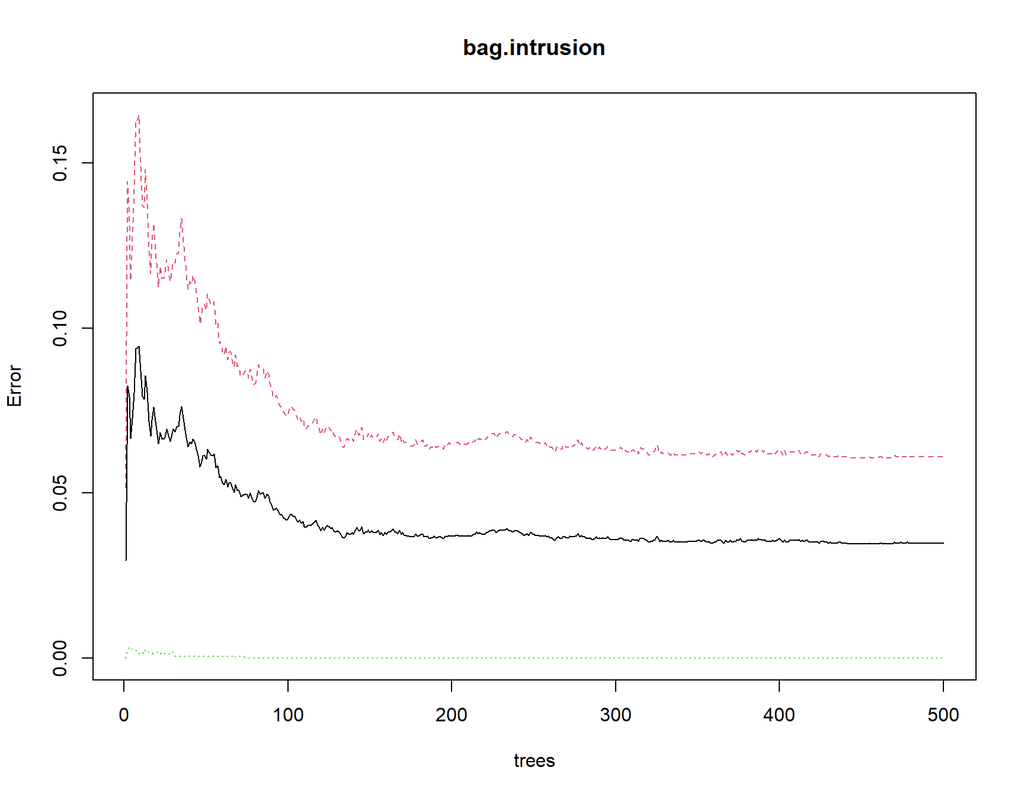

```r
plot(bag.intrusion)
```

```r
bag.pred = predict(bag.intrusion, newdata=intrusion.test)
bag.table = table(bag.pred, intrusion.test$is_intrusion)
message("test confusion matrix")
```

```
## test confusion matrix
```

```r
bag.table
```

```
##
## bag.pred   0   1
##        0 527   0
##        1  27 386
```

```r
message("test accuracy")
```

```
## test accuracy
```

```r
(bag.table[1,1]+bag.table[2,2])/sum(bag.table)
```

```
## [1] 0.9712766
```

```r
message("test sensitivity")
```

```
## test sensitivity
```

```r
bag.table[2,2]/sum(bag.table[,2])
```

```
## [1] 1
```

```r
bag.pred.rand = predict(bag.intrusion, newdata=intrusion.upsample.rand)
bag.table.rand = table(bag.pred.rand, intrusion.upsample.rand$is_intrusion)
message("test confusion matrix on large randomized dataset")
```

```
## test confusion matrix on large randomized dataset
```

```r
bag.table.rand
```

```
##
## bag.pred.rand     0     1
##             0 19493     0
##             1  1214  2292
```

```r
message("test accuracy on large randomized dataset")
```

```
## test accuracy on large randomized dataset
```

```r
(bag.table.rand[1,1]+bag.table.rand[2,2])/sum(bag.table.rand)
```

```
## [1] 0.9472151
```

```r
message("test sensitivity on large randomized dataset")
```

```
## test sensitivity on large randomized dataset
```

```r
bag.table.rand[2,2]/sum(bag.table.rand[,2])
```

```
## [1] 1
```

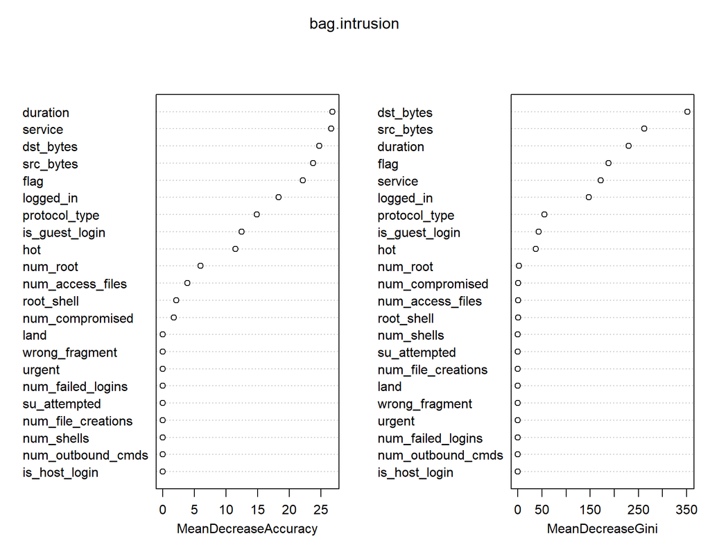

```r
varImpPlot(bag.intrusion)
```

A variable importance plot is included to give an idea of what variables are being used, and their importance to the data.

#### Random Forest

```r
# Random Forest

intrusion.rf = randomForest(is_intrusion~., intrusion.train, importance = TRUE)
intrusion.rf
```

```
##
## Call:
##  randomForest(formula = is_intrusion ~ ., data = intrusion.train,      importance = TRUE)
##                Type of random forest: classification
##                      Number of trees: 500
## No. of variables tried at each split: 4
##
##         OOB estimate of  error rate: 4.47%
## Confusion matrix:
##      0    1 class.error
## 0 1977  168  0.07832168
## 1    0 1614  0.00000000
```

```r
yhat.rf = predict(intrusion.rf ,newdata = intrusion.test)

summary(intrusion.rf)
```

```
##                 Length Class  Mode
## call               4   -none- call
## type               1   -none- character
## predicted       3759   factor numeric
## err.rate        1500   -none- numeric
## confusion          6   -none- numeric
## votes           7518   matrix numeric
## oob.times       3759   -none- numeric
## classes            2   -none- character
## importance        88   -none- numeric
## importanceSD      66   -none- numeric
## localImportance    0   -none- NULL
## proximity          0   -none- NULL
## ntree              1   -none- numeric
## mtry               1   -none- numeric
## forest            14   -none- list
## y               3759   factor numeric
## test               0   -none- NULL
## inbag              0   -none- NULL
## terms              3   terms  call
```

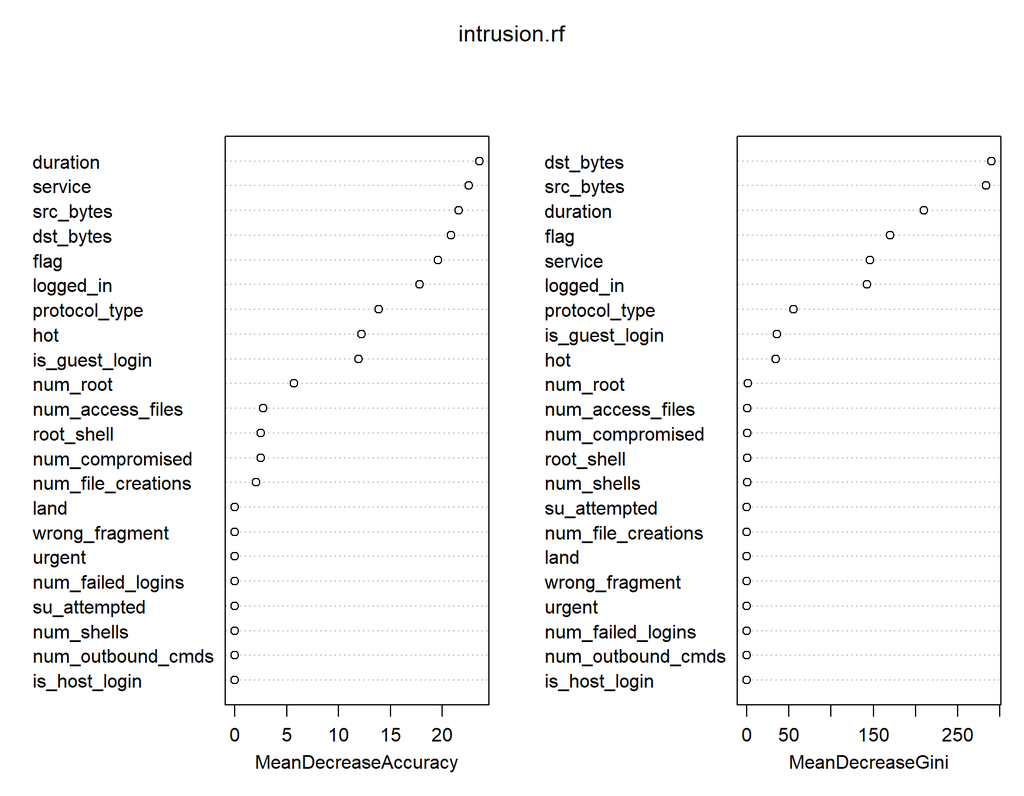

```r
varImpPlot(intrusion.rf)
```

- We can see the importance of different attributes and it give us an intuition about how to detect different types of intrusions. It is similar to what the tree indicated, like buffer overflow attacks, logged in attacks, protocol-specific attacks, traffic flooding and so on.

#### (c)Naive Bayes Classifier

```r
# Naive Bayes Classifier
set.seed(726)
trainIndex=createDataPartition(intrusion$is_intrusion, p=0.7)$Resample1
nb.train=intrusion[trainIndex, ]
nb.test=intrusion[-trainIndex, ]

#using the features we derived that have a large impact on Y
# P(Y = is_intrusion  | X = (service, duration, src_bytes))

model=naiveBayes(is_intrusion~duration+src_bytes+service, data=nb.train)

model
```

```
##
## Naive Bayes Classifier for Discrete Predictors
##
## Call:
## naiveBayes.default(x = X, y = Y, laplace = laplace)
##
## A-priori probabilities:
## Y
##   0   1
## 0.9 0.1
##
## Conditional probabilities:
##    duration
## Y      [,1]     [,2]
##   0 101.781 970.5106
##   1 275.300 448.7021
##
##    src_bytes
## Y         [,1]      [,2]
##   0   503.8254  1650.665
##   1 42317.1476 86330.316
##
##    service
## Y           auth     domain_u        eco_i        ecr_i       finger
##   0 0.0026455026 0.0650793651 0.0047619048 0.0037037037 0.0074074074
##   1 0.0000000000 0.0000000000 0.0000000000 0.0000000000 0.0000000000
##    service
## Y            ftp     ftp_data         http        ntp_u        other
##   0 0.0047619048 0.0354497354 0.6735449735 0.0074074074 0.0232804233
##   1 0.0952380952 0.2142857143 0.3238095238 0.0000000000 0.0000000000
##    service
## Y          pop_3      private         smtp       telnet         time
##   0 0.0026455026 0.0507936508 0.1121693122 0.0005291005 0.0005291005
##   1 0.0000000000 0.3666666667 0.0000000000 0.0000000000 0.0000000000
##    service
## Y          urp_i
##   0 0.0052910053
##   1 0.0000000000
```

```r
trainPred=predict(model, newdata = nb.train, type = "class")
trainTable=table(trainPred, nb.train$is_intrusion)
testPred=predict(model, newdata= nb.test, type = "class")
testTable=table(testPred, nb.test$is_intrusion)

trainAcc=(trainTable[1,1]+trainTable[2,2])/sum(trainTable)
testAcc=(testTable[1,1]+testTable[2,2])/sum(testTable)

message("Training Data")
```

```
## Training Data
```

```r
print(trainTable)
```

```
##
## trainPred    0    1
##         0 1867  177
##         1   23   33
```

```r
message("Test Data")
```

```
## Test Data
```

```r
print(testTable)
```

```
##
## testPred   0   1
##        0 798  81
##        1  11   9
```

```r
message("Accuracy")
```

```
## Accuracy
```

```r
print(round(cbind(trainAccuracy=trainAcc, testAccuracy=testAcc),4))
```

```
##      trainAccuracy testAccuracy
## [1,]        0.9048       0.8977
```

#### (c)Linear Discriminant Analysis

```r
intrusion.lda = lda(is_intrusion~duration+src_bytes+dst_bytes+service, data = nb.train)
intrusion.lda
```

```
## Call:
## lda(is_intrusion ~ duration + src_bytes + dst_bytes + service,
##     data = nb.train)
##
## Prior probabilities of groups:
##   0   1
## 0.9 0.1
##
## Group means:
##   duration  src_bytes dst_bytes servicedomain_u serviceeco_i serviceecr_i
## 0  101.781   503.8254 2981.3873      0.06507937  0.004761905  0.003703704
## 1  275.300 42317.1476  109.2048      0.00000000  0.000000000  0.000000000
##   servicefinger  serviceftp serviceftp_data servicehttp servicentp_u
## 0   0.007407407 0.004761905      0.03544974   0.6735450  0.007407407
## 1   0.000000000 0.095238095      0.21428571   0.3238095  0.000000000
##   serviceother servicepop_3 serviceprivate servicesmtp servicetelnet
## 0   0.02328042  0.002645503     0.05079365   0.1121693  0.0005291005
## 1   0.00000000  0.000000000     0.36666667   0.0000000  0.0000000000
##    servicetime serviceurp_i
## 0 0.0005291005  0.005291005
## 1 0.0000000000  0.000000000
##
## Coefficients of linear discriminants:
##                           LD1
## duration         2.205890e-04
## src_bytes        2.620954e-05
## dst_bytes       -7.214831e-06
## servicedomain_u  6.279758e-04
## serviceeco_i     7.061531e-04
## serviceecr_i     7.061531e-04
## servicefinger   -5.925711e-04
## serviceftp       4.664266e+00
## serviceftp_data  1.215227e+00
## servicehttp      3.119989e-01
## servicentp_u     5.806932e-04
## serviceother    -9.576320e-01
## servicepop_3     1.934395e-02
## serviceprivate   3.038000e+00
## servicesmtp     -4.196487e-02
## servicetelnet    2.094780e-02
## servicetime      1.080121e-03
## serviceurp_i    -2.997255e-03
```

```r
lda.pred = predict(intrusion.lda, nb.test)
lda.class = lda.pred$class
lda.table = table(lda.class, nb.test$is_intrusion)
lda.table
```

```
##
## lda.class   0   1
##         0 754  41
##         1  55  49
```

```r
lda.acc = (lda.table[1,1]+lda.table[2,2])/sum(lda.table)
message("Accuracy")
```

```
## Accuracy
```

```r
print(lda.acc)
```

```
## [1] 0.8932147
```

- LDA model has a similar accuracy to the Naive Bayes Classifier. But both of them do not perform well on sensitivity. So we think these models are not suitable for the intrusion data set.

#### (d)K-nearest Neighbors

```r
# K-nearest Neighbors
set.seed(53)
# we only choose `duration` and `src_bytes` to do 1-NN
standardized.X = scale(intrusion.upsample[,c(1,5)])

knn.test=sample(1:nrow(intrusion.upsample),1000)
train.X= standardized.X[-knn.test ,]
test.X= standardized.X[knn.test ,]
train.Y=intrusion.upsample$is_intrusion[-knn.test]
test.Y=intrusion.upsample$is_intrusion[knn.test]

set.seed(12)
knn.pred = knn(train.X, test.X, train.Y, k = 1)
#misclassification rate
mean(test.Y!=knn.pred)
```

```
## [1] 0.062
```

```r
con.matrix = table(knn.pred, test.Y)
con.matrix
```

```
##         test.Y
## knn.pred   0   1
##        0 481   0
##        1  62 457
```

```r
#Sensitivity
message("sensitivity")
```

```
## sensitivity
```

```r
con.matrix[2,2]/sum(con.matrix[,2])
```

```
## [1] 1
```

```r
#PPV
message("PPV")
```

```
## PPV
```

```r
con.matrix[2,2]/sum(con.matrix[2,])
```

```
## [1] 0.8805395
```

#### Try $K$ from 1 to 10

```r
sen = c()
for(k in seq(10)) {
  set.seed(53)
  knn.pred.k = knn(train.X, test.X, train.Y, k = k)
  con.matrix.k = table(knn.pred.k, test.Y)
  sen[k] = con.matrix.k[2,2] / sum(con.matrix[,2])
}

sen
```

```
##  [1] 1.0000000 0.9978118 0.9978118 0.9978118 0.9978118 0.9978118 0.9978118
##  [8] 0.9978118 0.9978118 1.0000000
```

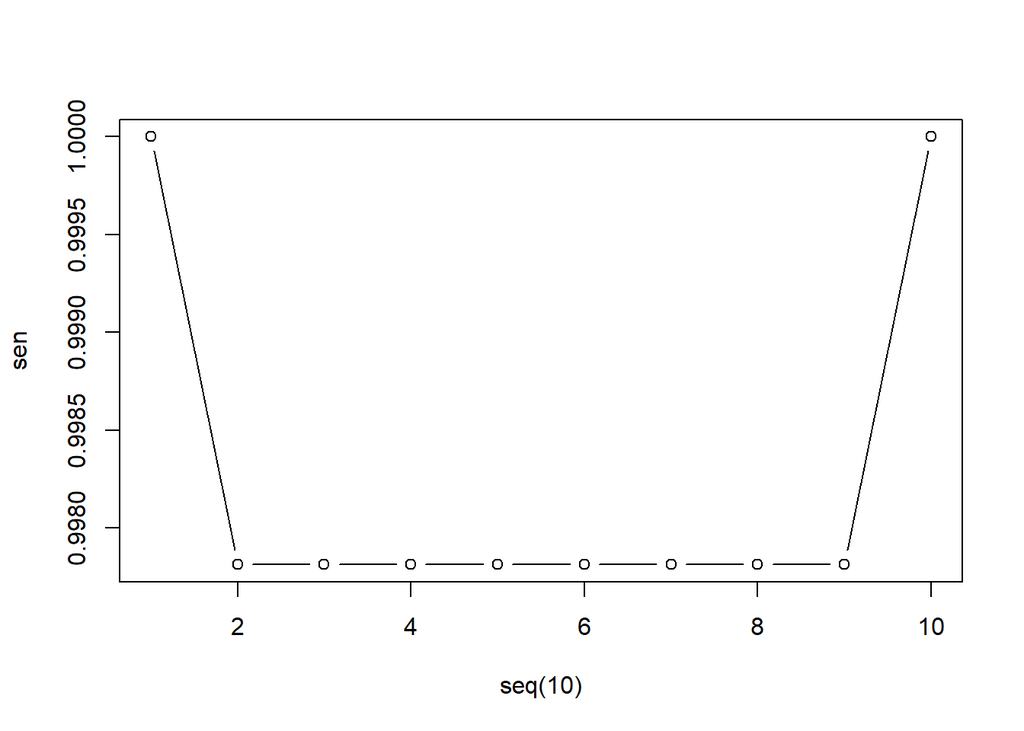

```r
plot(seq(10), sen, type = "b")
```

- All 10 KNN models have good sensitivity, so we simply choose the $k$ = 1 model.
- 1-NN classification model works perfectly with sensitivity = 1 and PPV = 0.8805
- However, it is inappropriate to use a KNN model to do real-time detection because it is a non-parametric “lazy learning” method and needs to look at the training data each time it is queried to make a classification.

### 2.3 Description

#### (a)`SF` Flag Decision Tree

### Now we try to use a decision tree model to fit `flag` = “SF” subdata separately. Because other flags are eigher all intrusions or non-intrusion. We want more details on classifying different types.

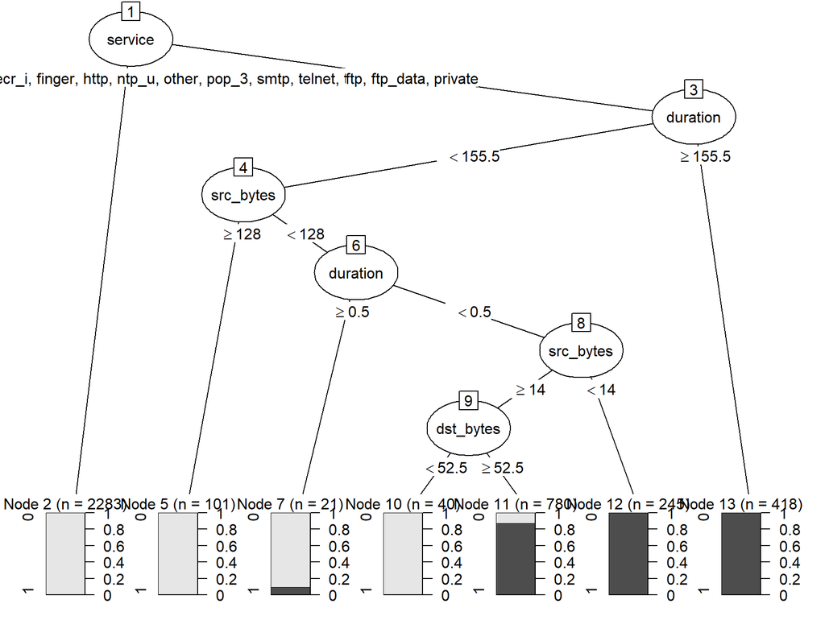

```r
# `SF` Flag Decision Tree
intrusion.SF = subset(intrusion.upsample, flag == "SF")

intrusion.SF$is_intrusion = as.factor(intrusion.SF$is_intrusion)
#intrusion.SF$src_bytes = as.factor(intrusion.SF$src_bytes)
intrusion.SF.tree = rpart(is_intrusion~., intrusion.SF)

intrusion.SF.party <- as.party(intrusion.SF.tree)

plot(intrusion.SF.party)
```

```r
print(intrusion.SF.party)
```

```
##
## Model formula:
## is_intrusion ~ duration + protocol_type + service + flag + src_bytes +
##     dst_bytes + land + wrong_fragment + urgent + hot + num_failed_logins +
##     logged_in + num_compromised + root_shell + su_attempted +
##     num_root + num_file_creations + num_shells + num_access_files +
##     num_outbound_cmds + is_host_login + is_guest_login
##
## Fitted party:
## [1] root
## |   [2] service in auth, domain_u, eco_i, ecr_i, finger, http, ntp_u, other, pop_3, smtp, telnet, time, urp_i: 0 (n = 2283, err = 0.0%)
## |   [3] service in ftp, ftp_data, private
## |   |   [4] duration < 155.5
## |   |   |   [5] src_bytes >= 128: 0 (n = 101, err = 0.0%)
## |   |   |   [6] src_bytes < 128
## |   |   |   |   [7] duration >= 0.5: 0 (n = 21, err = 9.5%)
## |   |   |   |   [8] duration < 0.5
## |   |   |   |   |   [9] src_bytes >= 14
## |   |   |   |   |   |   [10] dst_bytes < 52.5: 0 (n = 40, err = 0.0%)
## |   |   |   |   |   |   [11] dst_bytes >= 52.5: 1 (n = 780, err = 12.8%)
## |   |   |   |   |   [12] src_bytes < 14: 1 (n = 245, err = 0.4%)
## |   |   [13] duration >= 155.5: 1 (n = 418, err = 0.0%)
##
## Number of inner nodes:    6
## Number of terminal nodes: 7
```

- There are at least three types of intrusions. The party print out gives a good idea of how we can distinguish between benign and malicious connections with the same SF flag.

#### (b)K-clustering

To classify our flags we decided to use a k-clustering approach. Since it was not directly clear which intrusions were alike and manually sorting through it would be prohibitive. Since classification accuracy is not enough we n considered other metrics for our k cluster.

First we processed the data by mutating our categorical variables into factors a table below shows how each categorical variable converts to it’s numerical equaivalent.

#### Data processing

```r
set.seed(123)

# change flag, protocol_type and service into code numbers for k-clustering
intrusions.true <- intrusions.true %>%
  mutate(flag = as.factor(flag),
         protocol_type = as.factor(protocol_type),
         service = as.factor(service)
         )

intrusions.true <- intrusions.true %>%
  mutate(flag = as.numeric(flag),
         protocol_type = as.numeric(protocol_type),
         service = as.numeric(service),
                           )

#str(intrusions.true$flag)
#levels(intrusions.true$flag)

flag.table = data.frame(code = c("1","2","3","4"), name = c("RSTR","S0","S3","SF"))
protocol.table = data.frame(code = c("1","2"), name = c("tcp","udp"))
service.table = data.frame(code = c("1","2","3","4"), name = c("ftp","ftp_data","http","private"))

message("flag")
```

```
## flag
```

```r
flag.table
```

```
##   code name
## 1    1 RSTR
## 2    2   S0
## 3    3   S3
## 4    4   SF
```

```r
message("protocol_type")
```

```
## protocol_type
```

```r
protocol.table
```

```
##   code name
## 1    1  tcp
## 2    2  udp
```

```r
message("service")
```

```
## service
```

```r
service.table
```

```
##   code     name
## 1    1      ftp
## 2    2 ftp_data
## 3    3     http
## 4    4  private
```

#### K-Clustering

```r
set.seed(123)

intrusions.true[] <- lapply(intrusions.true, function(x) as.numeric(as.character(x)))

#km.res1 <- kmeans(na.omit(intrusions.true), 10, nstart = 50)

# for columns with all zeros, they are not used in k-clustering
intr.true.cleaned <- na.omit(intrusions.true)
# and only 10 attributes leave in cleaned data
intr.cleaned.var <- intr.true.cleaned[ , which(apply(intr.true.cleaned, 2, var) != 0)]

# scale the data
scaled_intrusions = as.matrix(scale(intr.cleaned.var))


km.res3 <- kmeans(scaled_intrusions, 7, nstart = 50)
#km.res4 <- kmeans(intr.cleaned.var, 8, nstart = 50)
km.res3
```

```
## K-means clustering with 7 clusters of sizes 100, 1, 53, 69, 33, 30, 14
##
## Cluster means:
##      duration protocol_type    service        flag  src_bytes  dst_bytes
## 1 -0.61096292     1.4118546  1.1167999  0.68590814 -0.4864121  0.1624812
## 2 -0.61100249    -0.7059273 -0.8954522  0.68590814 -0.4875096 -0.6210315
## 3  1.10430682    -0.7059273  0.1106739 -1.63178133  0.1613835 -0.6203083
## 4 -0.61100249    -0.7059273 -0.4142615 -0.06247899 -0.4875774 -0.6210315
## 5 -0.05293762    -0.7059273 -1.9015783  0.68590814 -0.4857605  2.6492669
## 6 -0.05701459    -0.7059273 -0.8954522  0.68590814  2.8594823 -0.6210315
## 7  3.48539888    -0.7059273  0.1106739 -1.54953393  0.3188468 -0.6210315
##          hot  logged_in    num_root is_guest_login
## 1 -0.3672127 -0.7112284 -0.05773503     -0.3509751
## 2 -0.3672127  1.4013313 17.26277305     -0.3509751
## 3 -0.3672127  1.4013313 -0.05773503     -0.3509751
```

[output cut: 46 more lines]

```r
# put the clusters we got into the copied intrusions.true data(named as intrusions.cluster with names instead of code numbers in it)
# create a new column called cluster(total 8 types)
cluster.val <- km.res3$cluster
intrusions.cluster$cluster <- cluster.val


k.max <- 15

wss <- sapply(1:k.max,
              function(k){kmeans(scaled_intrusions, k, nstart=50,iter.max = 15 )$tot.withinss})
message("Total within-clusters sum of squares")
```

```
## Total within-clusters sum of squares
```

```r
wss
```

```
##  [1] 2990.000000 1901.413578 1175.297034  783.501221  409.510235  388.657695
##  [7]   87.763937   85.530317   25.899460   23.539839   21.263346   20.807378
## [13]   20.609707   20.802742    5.023175
```

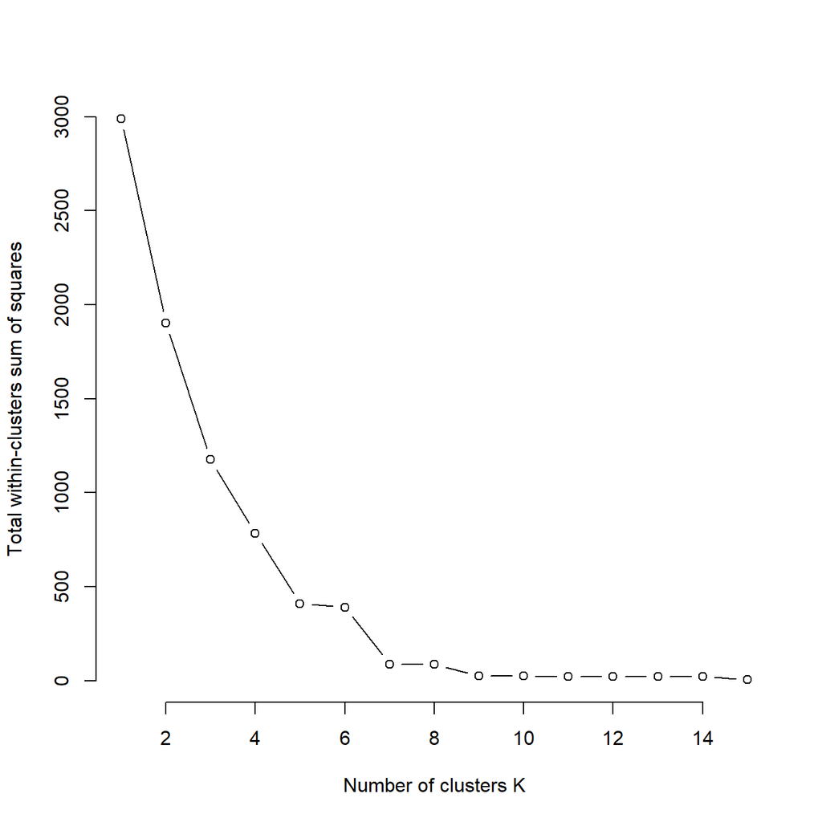

```r
plot(1:k.max, wss,
     type="b", pch = 1, frame = FALSE,
     xlab="Number of clusters K",
     ylab="Total within-clusters sum of squares")
```

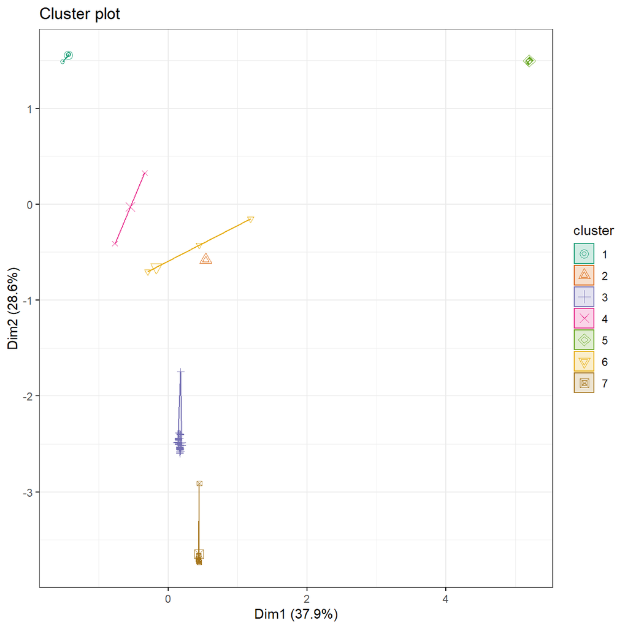

```r
# Show the cluster plot. We can only see two dimensions but actually there are 7.
fviz_cluster(km.res3, data = intr.cleaned.var,
             palette = "Dark2",
             geom = "point",
             ellipse.type = "convex",
             ggtheme = theme_bw()
             )
```

#### Clusters prediction with tree

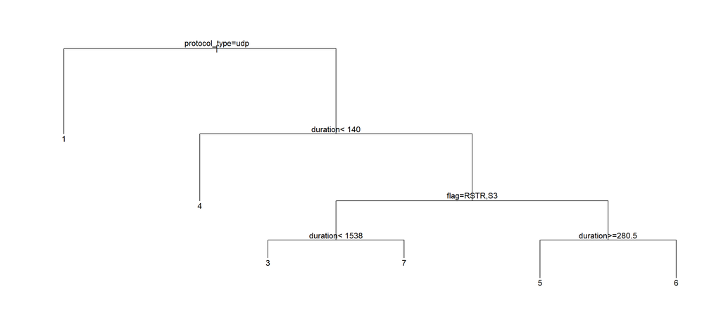

```r
set.seed(247)
# upsampling to get more data
intrusions.cluster.indx <- sample(1:nrow(intrusions.cluster), 10000, replace = TRUE)
intrusion.cluster.rand <-  intrusions.cluster[intrusions.cluster.indx, ]
#intrusions.mega <- rbind(intrusions.cluster, intrusion.cluster.rand)

cluster.test.indx <- sample(1:nrow(intrusion.cluster.rand), round(0.2 * nrow(intrusion.cluster.rand)))

intrusions.cluster.train <- intrusion.cluster.rand[-cluster.test.indx,]
intrusions.cluster.test <- intrusion.cluster.rand[cluster.test.indx,]
#intrusions.exp.train <-rbind(intrusions.cluster.train,intrusions.cluster)


intrusions.cluster.train$cluster = as.factor(intrusions.cluster.train$cluster)
#intrusions.exp.train$cluster = as.factor(intrusions.exp.train$cluster)
intrusion.cluster.tree = rpart(cluster~., intrusions.cluster.train)

#summary(intrusion.cluster.tree)

plot(intrusion.cluster.tree,compress = TRUE)
text(intrusion.cluster.tree, pretty = 0)
```

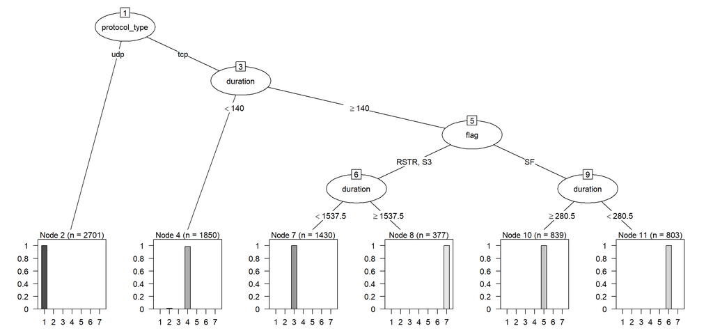

```r
intrusion.cluster.party <- as.party(intrusion.cluster.tree)

plot(intrusion.cluster.party)
```

```r
print(intrusion.cluster.party)
```

```
##
## Model formula:
## cluster ~ duration + protocol_type + service + flag + src_bytes +
##     dst_bytes + land + wrong_fragment + urgent + hot + num_failed_logins +
##     logged_in + num_compromised + root_shell + su_attempted +
##     num_root + num_file_creations + num_shells + num_access_files +
##     num_outbound_cmds + is_host_login + is_guest_login + is_intrusion
##
## Fitted party:
## [1] root
## |   [2] protocol_type in udp: 1 (n = 2701, err = 0.0%)
## |   [3] protocol_type in tcp
## |   |   [4] duration < 140: 4 (n = 1850, err = 1.5%)
## |   |   [5] duration >= 140
## |   |   |   [6] flag in RSTR, S3
## |   |   |   |   [7] duration < 1537.5: 3 (n = 1430, err = 0.0%)
## |   |   |   |   [8] duration >= 1537.5: 7 (n = 377, err = 0.0%)
## |   |   |   [9] flag in SF
## |   |   |   |   [10] duration >= 280.5: 5 (n = 839, err = 0.0%)
## |   |   |   |   [11] duration < 280.5: 6 (n = 803, err = 0.0%)
##
## Number of inner nodes:    5
## Number of terminal nodes: 6
```

```r
intrusion.cluster.pred = predict(intrusion.cluster.tree,
                                 newdata = intrusions.cluster.test, type ="class")

#intrusion.cluster.pred

table(intrusion.cluster.pred, intrusions.cluster.test$cluster)
```

```
##
## intrusion.cluster.pred   1   2   3   4   5   6   7
##                      1 693   0   0   0   0   0   0
##                      2   0   0   0   0   0   0   0
##                      3   0   0 333   0   0   0   0
##                      4   0   9   0 454   0   0   0
##                      5   0   0   0   0 212   0   0
##                      6   0   0   0   0   0 220   0
##                      7   0   0   0   0   0   0  79
```

- We can see that although we have 7 clusters, the tree only fit 6 of them. Probably because only a few number of observations are in cluster 2 and it is very similar to cluster 4 differieng only in that it accesses the root node..
- Cluster2 observations are classified into cluster 4, both share that they are using the ftp data protocol and have 12 source bytes. I suspect that cluster 2 intrusions write to the root and cluster 4 intrusions are copies generated by what is written, but that’s just an inference from the data.
- All other clusters have no error and are predicted accurately. There are distinct differences in the remaining clusters.
- So now we narrow down to 6 types of intrusions. We will describe them with more details and try to name each of them in 3.2.

### 2.4 Final Model Selection

- Decision Tree or Bagged Random Forest in 2.2 part(a), for predicting label `is_intrusion`
- Decision Tree in 2.3 part(b), for predicting the types of intrusion on `is_intrusion`==1 data set

## Section 3: Key Findings and Main Takeaways

### 3.2 Identify different types of intrusions

## Is it possible to identify different types of intrusions? If so, which values of which attributes in data correlate with the specific types of intrusions?

- Yes. Here are the intrusions we discovered and their corresponding features which dictate their “Intrusion Type” classification.
1. SYN Flooding Attack (Types 3, 4,and 7 - Type 7 appears to timeout or crash)

Description: A SYN flood attack consists on an attacker attempting to compromise a server by abusing the TCP handshake protocol. The attacker(client) sends as many SYN messages as possible to every open port on a server in an attempt to exhaust all of its available resources and rendering it useless. Typically the attacker will send only partial SYN messages or not send the response back to server in an attempt to not even engage the next steps of the handshake. These are typically used in conjunction with other attacks to wreck havoc.

Evidence: The flags “RSTR”, “S0” and “S3” lead to an intrusion 100% of the time. The “S0” and “S3” flags all are typical in a SYN flooding attack because these flags represent SYN messages with no acknowledgment.

2. Buffer Overflow Attack (Attack Type 6)

Description: This attack occurs when an adversary overwhelms the FTP server by feeding in a very large input that the buffer cannot store gracefully. This can be used to overwrite or extract areas of memory.

3. Man in the Middle Attack or UDP Flood (MITM) (Attack Type 1)

Description: A man in the middle attack is basically when an attacker sits between a client and a trusted source. The attacker can either pose as the trusted source or eavesdrop on the communication. Trusted sites typically will use a certificate to authenticate its security. Attackers can sometimes spoof these certificates in order to pose as a more trusted source.

4. FTP Anonymous Login Attack (Attack Type = 5, Type 2)

Description: This attack is successful when an organization has not properly configured their FTP settings. Some FTP servers allow for anonymous login, this means that anyone who uses the default “anoymous:anoymous” login credentials will have access to the FTP server.

### 3.3 Detecting System

- Develop and implement a systematic approach to detect instances of intrusions in log files. Your system will need to **be able to take a new network_traffic log file** and determine the existence of known patterns of intrusions as well as anomalies which may be indicative of new and unknown intrusion patterns.

### 3.4 Evaluate detection power of the system.

> Input:

| Argument | Description |
| --- | --- |
| `file` | the name of the new log file(“name.csv”)make sure it’s under working directory |
| `cluster.tree` | a rpart tree object to predict clusters, use intrusion.cluster.tree as default |

> Output:

The output will be a **list** containing the following elements

[output not shown]

```r
detectSystem <- function(file, intrusion.tree = intrusion.tree, intrusion.cluster.tree = intrusion.cluster.tree,
                         flag.table = flag.table, protocol.table = protocol.table, service.table = service.table) {

  set.seed(456)

  # data processing
  # load the new log file (If detect in real-time, read the updated line)
  traffic <- read.csv(file)
  # clean the data : remove NA

  traffic <- na.omit(traffic)

  # intrusion prediction
  pred_intrusion <- predict(intrusion.tree, newdata = traffic, type = "class")
  pred_intrusion <- data.frame(pred_intrusion = pred_intrusion)

  # add a new column `pred_intrusion`
  traffic <- cbind(traffic, pred_intrusion)

  # prediction == 1 data set
  intru.pred.true <- traffic[traffic$pred_intrusion == 1,]

  if(is.null(intru.pred.true)) {
    potential_intru = FALSE
  } else {
    potential_intru = TRUE
  }

  # assume no unknown intrusion types existing
  new_cluster = FALSE
  if(potential_intru) {
    # the cluster tree can only fit existing factors
    intru.true.merge = merge(intru.pred.true, flag.table, by.x = "flag", by.y = "name" , all = TRUE, sort = FALSE)
    intru.true.merge = merge(intru.true.merge, protocol.table,
                             by.x = "protocol_type", by.y = "name" , all = TRUE, sort = FALSE)
    intru.true.merge = merge(intru.true.merge, service.table,
                             by.x = "service", by.y = "name" , all = TRUE, sort = FALSE)

    # find out if there is unknown intrusion type
    if(anyNA(intru.true.merge)) {
      new_cluster = TRUE
      intru.true.clean = na.omit(intru.true.merge)

    } else {
      intru.true.clean = intru.true.merge
    }
    # clusters prediction
    intru.cluster.pred = predict(intrusion.cluster.tree, newdata = intru.true.clean, type = "class")
    intru_clusters = summary(intru.cluster.pred)
  }


  res = list(potential_intru = potential_intru, new_cluster = new_cluster, intru_clusters = intru_clusters)
  res
}
```

#### Use this code to test the system

```r
res = detectSystem(file = "network_traffic.csv", intrusion.tree = intrusion.tree,
                   intrusion.cluster.tree = intrusion.cluster.tree, flag.table = flag.table,
                   protocol.table = protocol.table, service.table = service.table)

res
```

```
## $potential_intru
## [1] TRUE
##
## $new_cluster
## [1] TRUE
##
## $intru_clusters
##   1   2   3   4   5   6   7
## 219   0  53  69  33  30  14
```

#### Use this code to test the system

### 3.5 Real-time detection & information exchanges

- Can your intrusion detector be used in real-time? It would need to be able to receive data about a current session, and in seconds determine if it is likely to be and intrusion of previously seen type or an anomaly potentially signifying an unseen yet intrusion mode. What information should be exchanged via the user interface of such system?

We can also tell whether an intrusion is an anomaly by predicting whether or not the new data is an intrusion and checking if any row values differ from our established types.

## References

[Information about the attack types](https://www.netscout.com/what-is-ddos/udp-flood) [Common DDoS attacks](https://www.cloudflare.com/learning/ddos/syn-flood-ddos-attack/) [TCP Port Scanning](http://etutorials.org/Networking/network+security+assessment/Chapter+4.+IP+Network+Scanning/4.2+TCP+Port+Scanning/) [The 10 Most Common Types of Cyber Attacks](https://blog.netwrix.com/2018/05/15/top-10-most-common-types-of-cyber-attacks//)